# Reproducible Reports Assignment - Course Project 1

The data in this assignment, provided by course instructors, was from a personal activity monitoring device that collects data at 5-minute intervals. The data was downloaded from the course website. The variables were: 1) steps, number of steps taken at 5-min intervals; 2) date, date measurement was taken, and 3) interval, indentifier for the 5-min intervals. R codes to read and analyze the data, along with analysis results are presented below.

```r
# read data
setwd("C:/Users/user/DataScience_Coursera/repdata-data-activity/")
activity <- read.csv("activity.csv", stringsAsFactors=FALSE, header=TRUE)

#format variables
activity$date <- as.Date(as.character(activity$date))

# exclude missing values
activity_complete <- na.exclude(activity)
```

# What is the mean total number of steps taken per day?

```r
total_steps_per_day <- aggregate(activity_complete$steps, by=list(date=activity_complete$date), sum)

colnames(total_steps_per_day) <- c("date", "total.steps")
```

# 1. Total number of steps per day

```r
total_steps_per_day
```

```
##          date total.steps
## 1  2012-10-02         126
## 2  2012-10-03       11352
## 3  2012-10-04       12116
## 4  2012-10-05       13294
## 5  2012-10-06       15420
## 6  2012-10-07       11015
## 7  2012-10-09       12811
## 8  2012-10-10        9900
## 9  2012-10-11       10304
## 10 2012-10-12       17382
## 11 2012-10-13       12426
## 12 2012-10-14       15098
## 13 2012-10-15       10139
## 14 2012-10-16       15084
```

[output cut: 39 more lines]

# 2. Histogram of total number of steps per day

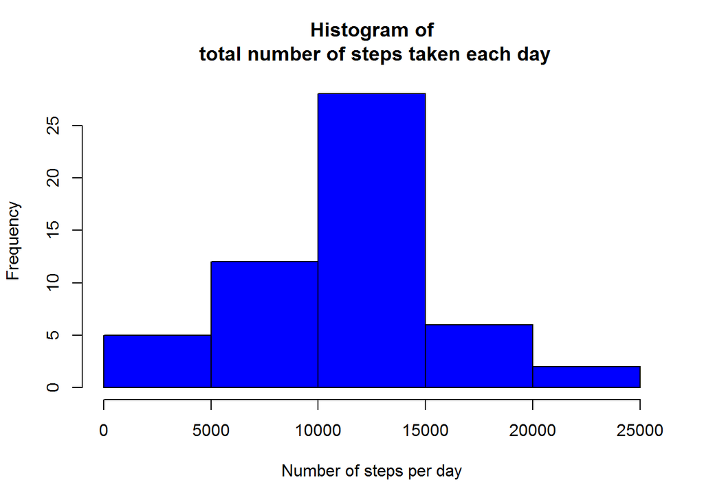

```r
hist(total_steps_per_day$total.steps, col="blue", xlab="Number of steps per day", main="Histogram of\n total number of steps taken each day")
```

# 3.Mean and median total number of steps per day

```r
summary(total_steps_per_day$total.steps)
```

```
##    Min. 1st Qu.  Median    Mean 3rd Qu.    Max.
##      41    8841   10760   10770   13290   21190
```

# What is the average daily activity pattern?

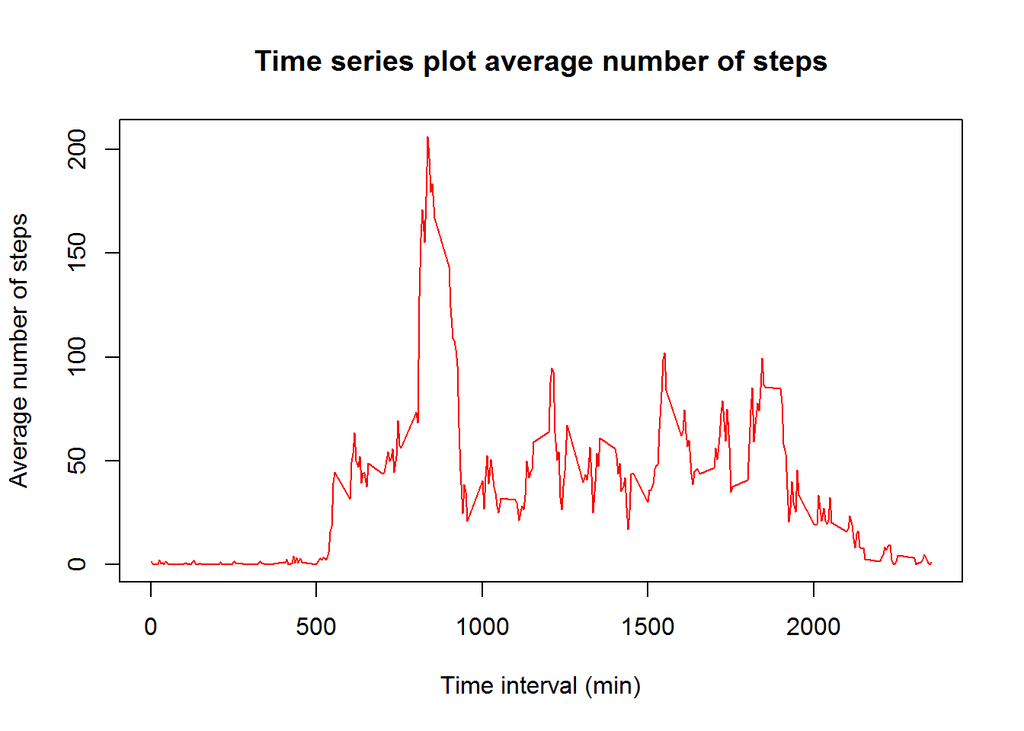

```r
average_steps_per_interval <- aggregate(activity_complete$steps, by=list(interval=activity_complete$interval), mean)

colnames(average_steps_per_interval) <- c("interval", "average.steps")

plot(x=average_steps_per_interval$interval, y=average_steps_per_interval$average.steps, type='l', col=2, xlim=c(0,max(average_steps_per_interval$interval)),
     xlab="Time interval (min)", ylab="Average number of steps",
     main="Time series plot average number of steps")
```

# The 5-minute interval that displays the max average number of steps:

```r
average_steps_per_interval[which.max(average_steps_per_interval$average.steps),]
```

```
##     interval average.steps
## 104      835      206.1698
```

# 1. Number of missing values

```r
sum(is.na(activity))
```

```
## [1] 2304
```

# 2. creating a new data set with mean imputation

```r
require(Hmisc)
activity$imputed.steps <- with(activity, impute(steps, mean))
```

# 3. Histogram of total number of steps per day in imputed data set

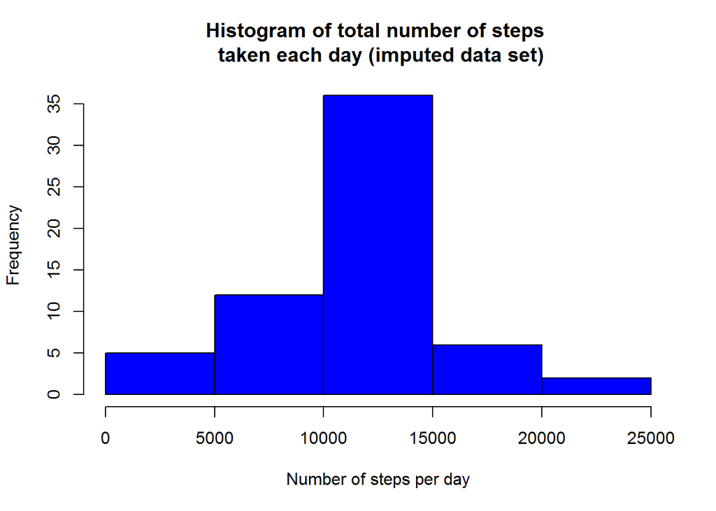

```r
total_number_steps_a_day <- aggregate(activity$imputed.steps, by=list(date=activity$date), sum)

colnames(total_number_steps_a_day) <- c("date", "total.steps")

hist(total_number_steps_a_day$total.steps, col="blue", xlab="Number of steps per day", main="Histogram of total number of steps \n taken each day (imputed data set)")
```